# Project1

Yan Wang

2023-09-09

## Part 1: Explore data

### 1

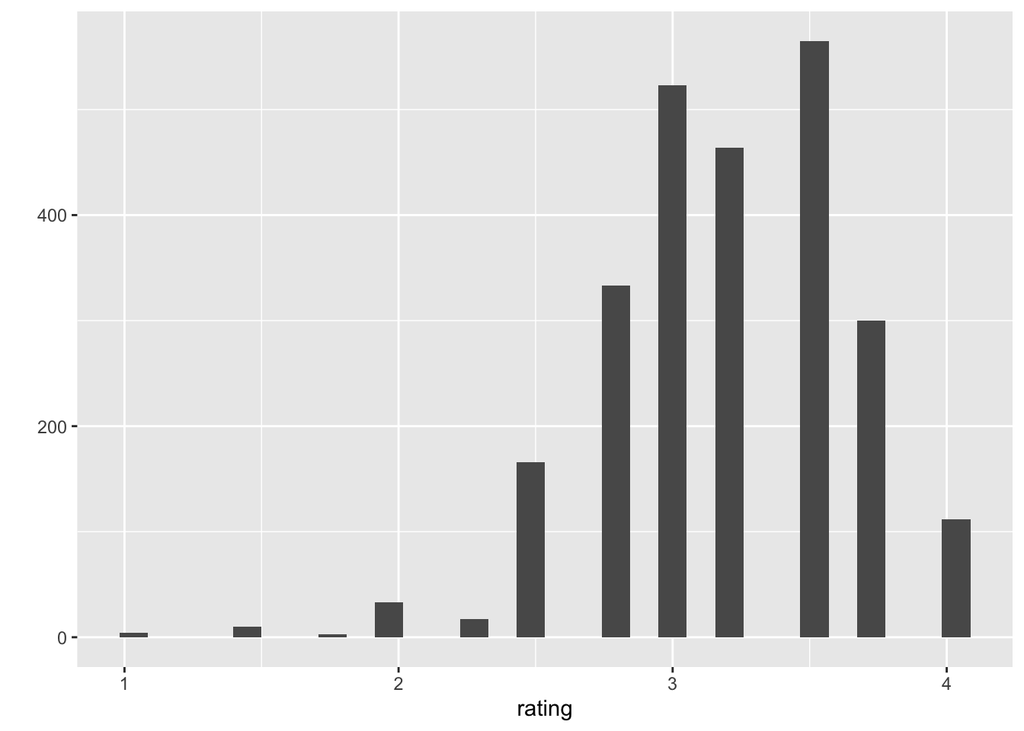

```r
library(dplyr)
library(ggplot2)
qplot(rating, data = chocolate)
```

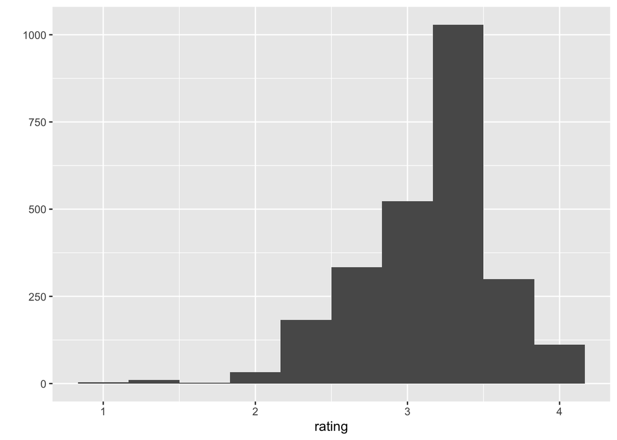

```r
qplot(rating, data = chocolate, bins = 10)
```

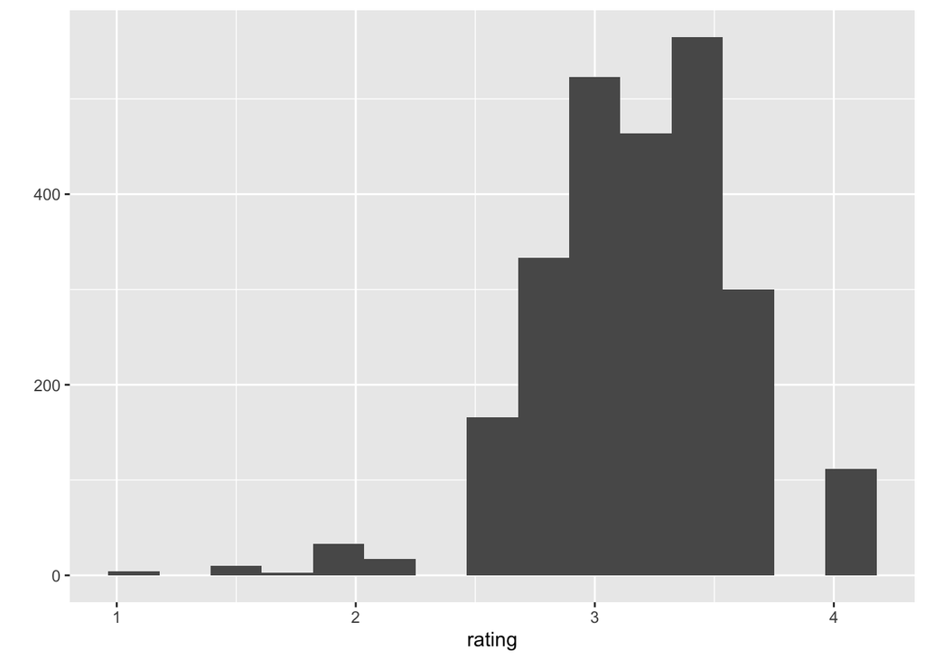

```r
qplot(rating, data = chocolate, bins = 15)
```

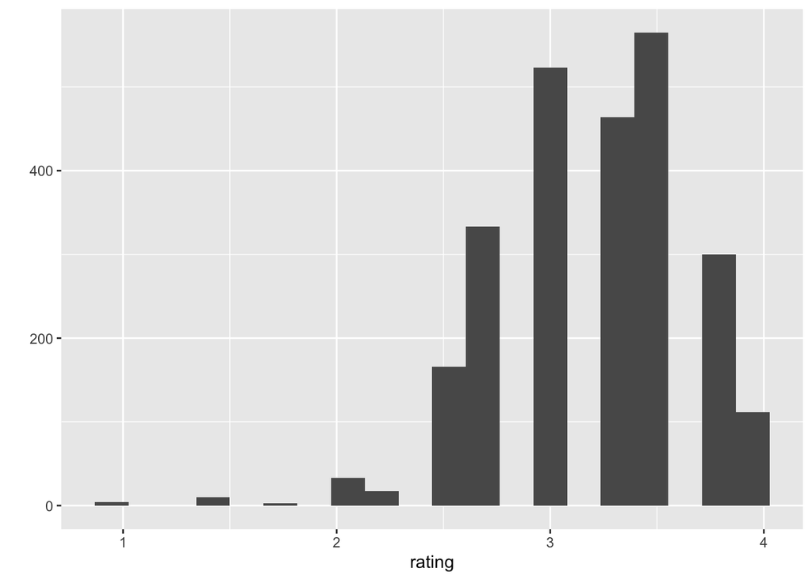

```r
qplot(rating, data = chocolate, bins = 20)
```

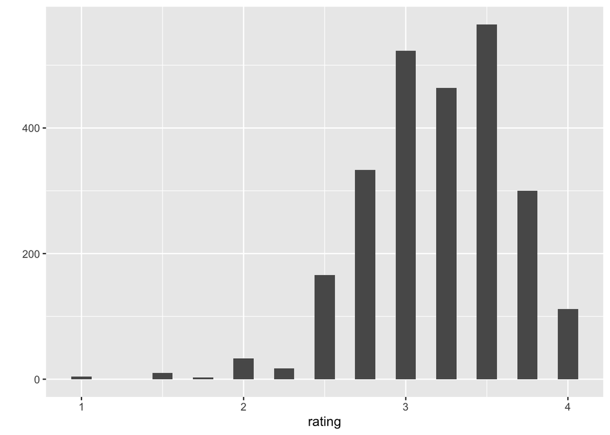

```r
qplot(rating, data = chocolate, bins = 25)
```

#### Answer: When I change the number of bins from 10, to 15, 20, 25, and default (30), these bars become more separately and bin size becomes more narrower, which, in my opinion, would be helpful to identify the characteristics in the data. I picked 25 because it shows these bars clealry and at the same time, the distribution of data is also clealy displayed.

### 2

```r
counties <- group_by(chocolate, country_of_bean_origin)
tibble <- count(counties)
print(tibble)
```

```
## # A tibble: 62 × 2
## # Groups:   country_of_bean_origin [62]
##    country_of_bean_origin     n
##    <chr>                  <int>
##  1 Australia                  3
##  2 Belize                    76
##  3 Blend                    156
##  4 Bolivia                   80
##  5 Brazil                    78
##  6 Burma                      1
##  7 Cameroon                   3
##  8 China                      1
##  9 Colombia                  79
## 10 Congo                     11
## # ℹ 52 more rows
```

#### Answer: There are total 62 countries where the beans originated from. The total reviews for each country of bean origin are displayed in the tibble above. For example, Australia has 3 reviews, Belize has 76 reviews, etc.

### 3

```r
ecuador <- filter(chocolate, country_of_bean_origin == "Ecuador")
ecuador1 <- data.frame(summarise(ecuador, mean = mean(rating), sd = sd(rating), total = n()))
ecuador1
```

```
##       mean        sd total
## 1 3.164384 0.5122678   219
```

#### Answer: The average rating scores, the total number of reviews, and the standard deviation of the rating scores are 3.16, 219, and 0.51 respectively.

### 4

```r
ecuadors <- group_by(ecuador, specific_bean_origin_or_bar_name)
ecuadorss <- data.frame(summarise(ecuadors, quality = mean(rating)))
arrange(ecuadorss, desc(quality))
```

```
##                   specific_bean_origin_or_bar_name  quality
## 1                                    Corona Arriba 4.000000
## 2                                           Guayas 4.000000
## 3      Porcelana, Sorotaima,Machiques,batch pcl001 4.000000
## 4                                    Rio Peripa H. 4.000000
## 5                                          Tangara 4.000000
## 6                                           Alpaco 3.750000
## 7     Camino Verde P., Balao, 2015 harvest, batch8 3.750000
## 8               Camino Verde, 2017 h., batch EC019 3.750000
## 9               Corazon del Ecuador, Calceta beans 3.750000
## 10                       Costa Esmeralda, Batch 30 3.750000
## 11                  Costa Esmeraldas, Salazar Farm 3.750000
## 12                           Ecuador, lot E432314L 3.750000
## 13                        Esmeraldas, Salazar Farm 3.750000
## 14                             Esmeraldas, batch 9 3.750000
```

[output cut: 106 more lines]

#### Answer: Corona Arriba, Guayas, Porcelana, Sorotaima,Machiques,batch pcl001, Rio Peripa H., and Tangaramake the best chocolate with beans from Ecuador.

### 5

```r
country_rate <- group_by(chocolate, country_of_bean_origin)
country_rates <- data.frame(summarise(country_rate, rates = mean (rating)))
arrange(country_rates, desc(rates))
```

```
##    country_of_bean_origin    rates
## 1                  Tobago 3.625000
## 2                   China 3.500000
## 3     Sao Tome & Principe 3.500000
## 4         Solomon Islands 3.450000
## 5                   Congo 3.318182
## 6                Thailand 3.300000
## 7                    Cuba 3.291667
## 8                 Vietnam 3.287671
## 9        Papua New Guinea 3.280000
## 10             Madagascar 3.266949
## 11                  Haiti 3.266667
## 12                 Brazil 3.262821
## 13              Guatemala 3.258065
## 14              Nicaragua 3.255000
```

[output cut: 48 more lines]

#### Answer: The top 3 countries with the highest ratings on average are Tobago, China, and Sao Tome & Principe.

### 6

```r
country_rate1 <- mutate(country_rate, n = n())
country_rate2 <- filter(country_rate1, n >= 10)
country_rate3 <- data.frame(summarise(country_rate2, rates3 = mean(rating)))
arrange(country_rate3, desc(rates3))
```

```
##    country_of_bean_origin   rates3
## 1         Solomon Islands 3.450000
## 2                   Congo 3.318182
## 3                    Cuba 3.291667
## 4                 Vietnam 3.287671
## 5        Papua New Guinea 3.280000
## 6              Madagascar 3.266949
## 7                   Haiti 3.266667
## 8                  Brazil 3.262821
## 9               Guatemala 3.258065
## 10              Nicaragua 3.255000
## 11               Trinidad 3.244048
## 12                 U.S.A. 3.242424
## 13               Honduras 3.240000
## 14               Tanzania 3.234177
```

[output cut: 21 more lines]

#### Answer: Solomon Islands, Congo, and Cuba have the highest ratings on average after removing countries of bean origins that have less than 10 reviews.

### 7

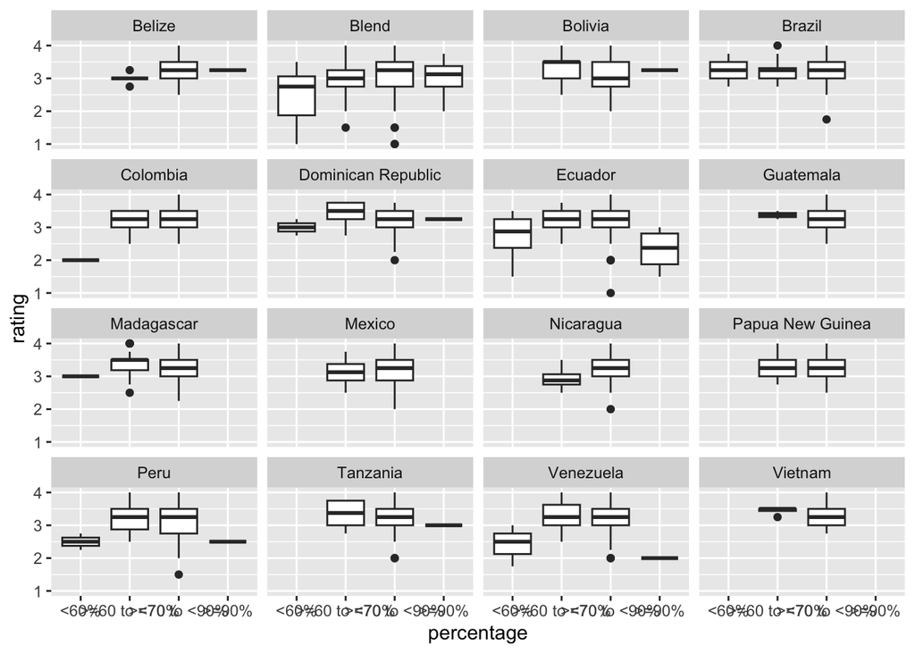

```r
library(dplyr)
library(tidyr)
library(lubridate)
country_rate4 <- filter(country_rate1, n >= 50)
country_rate6 <- mutate(country_rate4, percentage = case_when(
  cocoa_percent < 60 ~ "<60%",
  cocoa_percent >= 60 & cocoa_percent < 70 ~ ">=60 to <70%",
  cocoa_percent >= 70 & cocoa_percent < 90 ~ ">=70 to <90%",
  cocoa_percent >= 90 ~ ">=90%"
) )
library(forcats)
country_rate6$percentage <- fct_relevel(country_rate6$percentage, "<60%", ">=60 to <70%", ">=70 to <90%", ">=90%")
country_rate7 <- country_rate6[, c("percentage", setdiff(names(country_rate6), "percentage"))]
country_rate8 <- data.frame(arrange(country_rate7, percentage))
ggplot(country_rate8, aes(x = percentage, y = rating)) + geom_boxplot() + facet_wrap(~country_of_bean_origin)
```

#### Answer: From the boxplots displayed above, chocolate percentage within “60%~90%” seems most highly rated. Most countries agree with the rating.

## Part 2: Join two datasets together

```r
library(gapminder)
library(dplyr)
newdata <- gapminder
newdata1 <- select(newdata, 1:2)
newdata2 <- rename(newdata1, country_of_bean_origin = country)
chocolate1 <- left_join(x = chocolate, y = newdata2, by = "country_of_bean_origin")
```

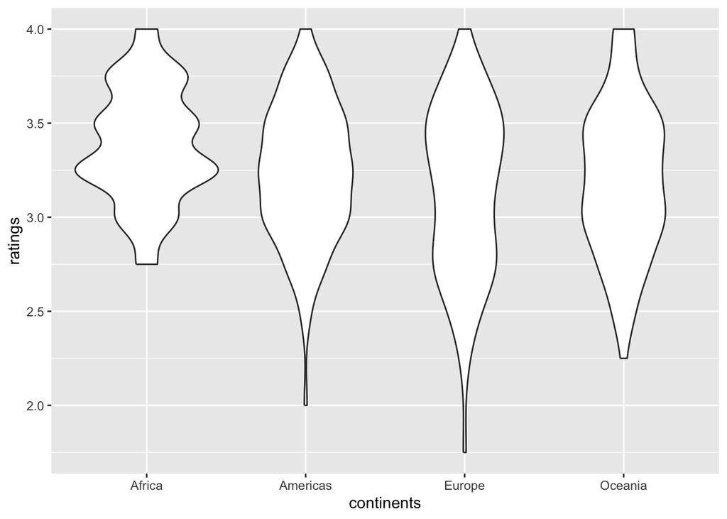

```r
chocolate2 <- group_by(chocolate1, country_of_bean_origin)
chocolate3 <- mutate(chocolate2, reviews = n())
chocolate4 <- filter(chocolate3, reviews >= 10)
chocolate5 <- subset(chocolate4, country_of_bean_origin!="Blend")
chocolate6 <- chocolate5[is.na(chocolate5$continent),] %>%
mutate(continent = case_when(
      country_of_bean_origin %in% c('Fiji', 'Papua New Guinea', 'Sao Tome') ~ 'Oceania',
      country_of_bean_origin %in% c('Congo', 'Solomon Islands') ~ 'Africa',
      country_of_bean_origin %in% c('Vanuatu') ~ 'Europe',
      country_of_bean_origin %in% c('Trinidad', 'Grenada', 'St. Lucia') ~ 'Europe',
      country_of_bean_origin %in% c('U.S.A.', 'Belize') ~ 'Americas'))
ggplot(chocolate6, aes(x = continent, y = rating)) + geom_violin() + labs(x= "continents", y = "ratings")
```

## Part 3: Convert wide data into long data

```r
library(dplyr)
library(tidyr)
newchocolate <- chocolate %>% mutate(beans = case_when(grepl("B", ingredients) ~ 1, TRUE ~ 0)) %>% mutate(sugar = case_when(grepl("S", ingredients) ~ 1, TRUE ~ 0)) %>% mutate(cocoa_butter = case_when(grepl("C", ingredients) ~ 1, TRUE ~ 0)) %>% mutate(vanilla = case_when(grepl("V", ingredients) ~ 1, TRUE ~ 0)) %>% mutate(letchin = case_when(grepl("L", ingredients) ~ 1, TRUE ~ 0)) %>% mutate(salt = case_when(grepl("Sa", ingredients) ~ 1, TRUE ~ 0))
library(stringr)
newchocolate1 <- newchocolate %>% mutate(char_cocoa = case_when(str_detect(most_memorable_characteristics, "cocoa") ~1, TRUE ~ 0)) %>% mutate(char_sweet = case_when(str_detect(most_memorable_characteristics, "sweet") ~1, TRUE ~ 0)) %>% mutate(char_nutty = case_when(str_detect(most_memorable_characteristics, "nutty") ~1, TRUE ~ 0)) %>% mutate(char_creamy = case_when(str_detect(most_memorable_characteristics, "creamy") ~1, TRUE ~ 0)) %>% mutate(char_roasty = case_when(str_detect(most_memorable_characteristics, "roasty") ~1, TRUE ~ 0)) %>% mutate(char_earthy = case_when(str_detect(most_memorable_characteristics, "earthy") ~1, TRUE ~ 0))
newchocolate2 <- group_by(newchocolate1, review_date)
newchocolate3 <- data.frame(summarise(newchocolate2, beansm = mean(beans), sugarm = mean(sugar), cocoa_butterm = (cocoa_butter), vanillam = mean(vanilla), letchinm = mean(letchin), saltm = mean(salt), char_cocoam = mean(char_cocoa), char_sweetm = mean(char_sweet), char_nuttym = mean(char_nutty), char_creamym = mean(char_creamy), char_roastym = mean(char_roasty), char_earthym = mean(char_earthy)))
newchocolate3 %>% pivot_longer(-review_date, names_to = "feature", values_to = "mean_score")
```

```
## # A tibble: 30,360 × 3
##    review_date feature       mean_score
##          <dbl> <chr>              <dbl>
##  1        2006 beansm            0.968
##  2        2006 sugarm            0.968
##  3        2006 cocoa_butterm     1
##  4        2006 vanillam          0.694
##  5        2006 letchinm          0.694
##  6        2006 saltm             0
##  7        2006 char_cocoam       0.210
##  8        2006 char_sweetm       0.161
##  9        2006 char_nuttym       0.0323
## 10        2006 char_creamym      0.242
## # ℹ 30,350 more rows
```

```r
newchocolate4 <- tibble(newchocolate3 %>% pivot_longer(-review_date, names_to = "feature", values_to = "mean_score"))
print(newchocolate4)
```

```
## # A tibble: 30,360 × 3
##    review_date feature       mean_score
##          <dbl> <chr>              <dbl>
##  1        2006 beansm            0.968
##  2        2006 sugarm            0.968
##  3        2006 cocoa_butterm     1
##  4        2006 vanillam          0.694
##  5        2006 letchinm          0.694
##  6        2006 saltm             0
##  7        2006 char_cocoam       0.210
##  8        2006 char_sweetm       0.161
##  9        2006 char_nuttym       0.0323
## 10        2006 char_creamym      0.242
## # ℹ 30,350 more rows
```

### Part 4: Data visualization

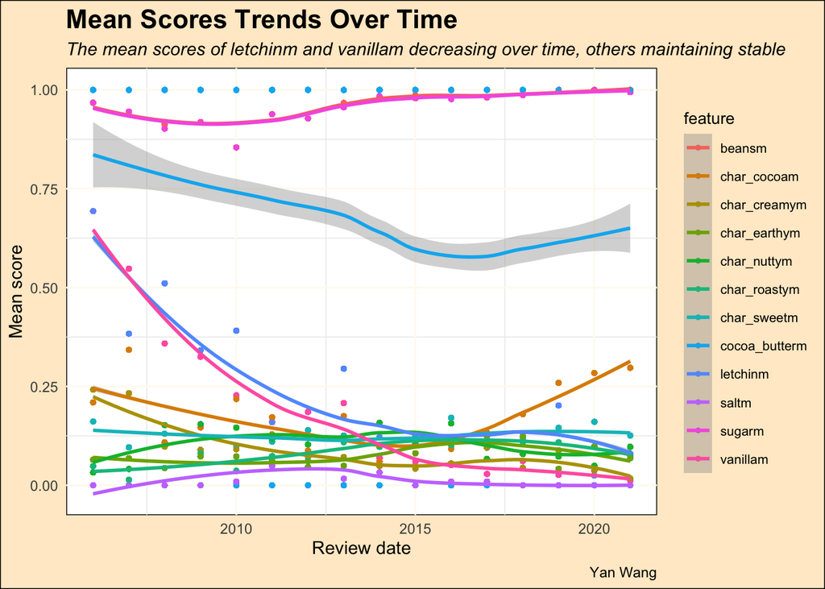

```r
library(ggplot2)
ggplot(newchocolate4, aes(x = review_date, y = mean_score, color = feature)) + geom_point(size = 1) + geom_smooth(method = "loess", formula = "y~x") + labs(title = "Mean Scores Trends Over Time", subtitle = "The mean scores of letchinm and vanillam decreasing over time, others maintaining stable", caption = "Yan Wang", x= "Review date", y = "Mean score") + theme_minimal() + theme(plot.background = element_rect(fill = "#FFEBCD"), panel.background = element_rect(fill = "white"), panel.grid.major = element_line(color = "#FFFAF0"), plot.title = element_text(size = 16, face = "bold"),plot.subtitle = element_text(size = 11, face = "italic"), legend.position = "right", legend.text = element_text(size = 8), legend.title = element_text(size = 10))
```

### Part 5: Make the worst plot you can!

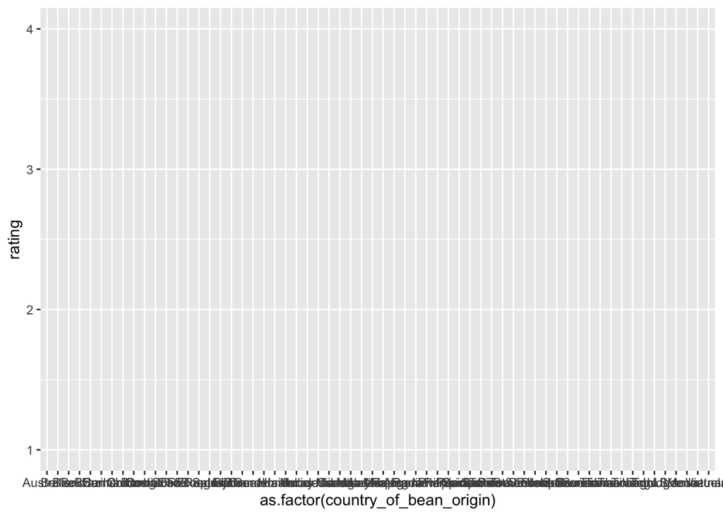

```r
chocolate %>% ggplot(aes(x = as.factor(country_of_bean_origin), y = rating))
```

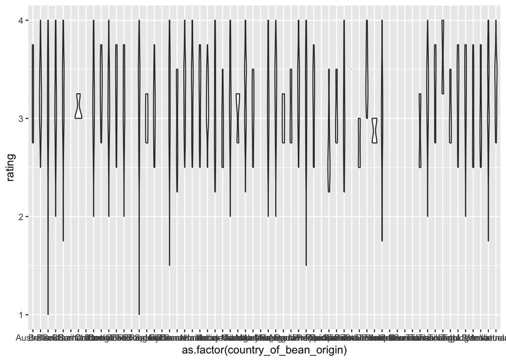

```r
chocolate %>% ggplot(aes(x = as.factor(country_of_bean_origin), y = rating)) + geom_violin()
```

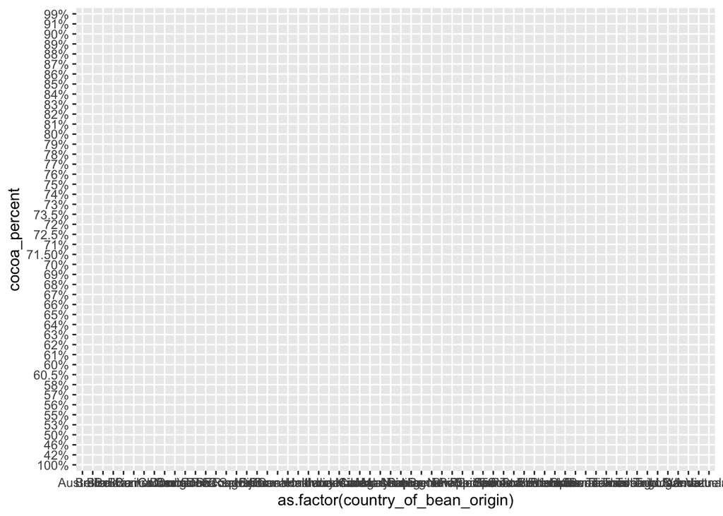

```r
chocolate %>% ggplot(aes(x = as.factor(country_of_bean_origin), y = cocoa_percent))
```

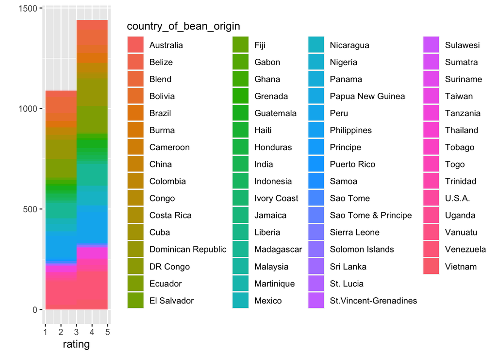

```r
qplot(rating, data = chocolate, fill = country_of_bean_origin, binwidth = 2)
```

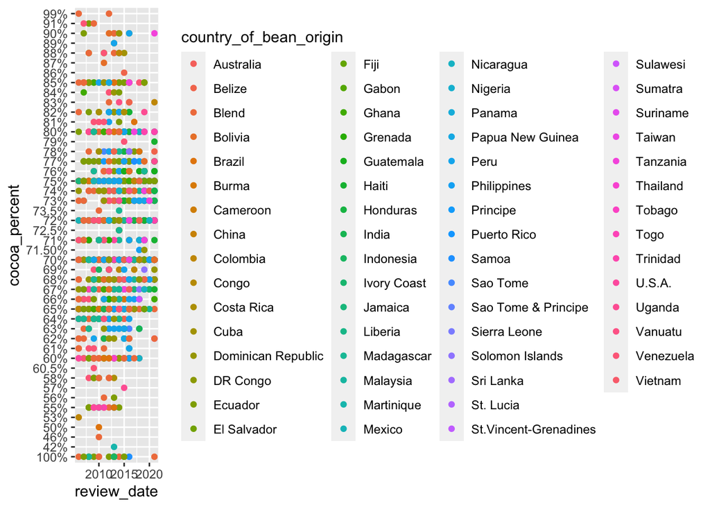

```r
qplot(review_date, cocoa_percent, data = chocolate, color = country_of_bean_origin)
```

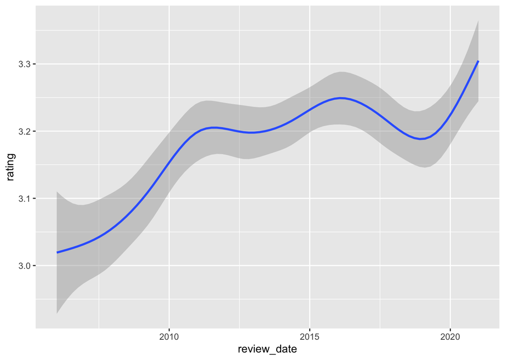

```r
qplot(review_date, rating, data = chocolate, geom = c("smooth"))
```

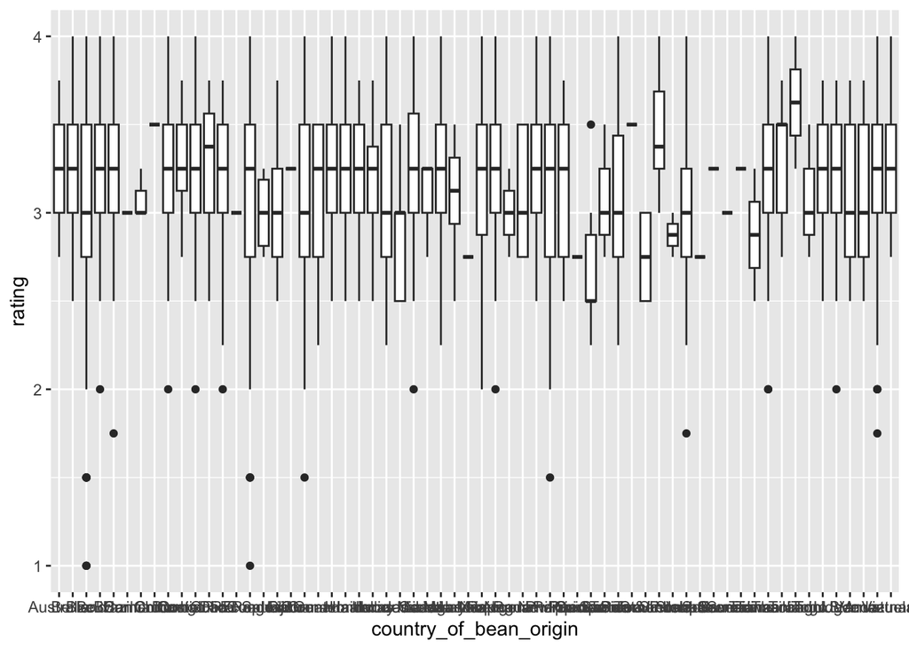

```r
qplot(country_of_bean_origin, rating, data = chocolate, geom = "boxplot")
```

#### Answer:

##### 1. It suggests that points should be displayed clearly and easy to understand at a glance. Clutter should be avoided.

##### 2. It suggests that I should choose the right type of graphs to best represent the data.

##### 3. It suggests that I should design the x-axis and y-axis properly.

##### 4. It suggests that I should focus on visualizing the most meaningful aspects of the data.

##### 5. It suggests that removing any unnecessary elements is important.

##### 6. It suggests that providing clear labels for axes, data points, title, etc are important and meaningful.

##### 7. It suggests that choosing the proper graphs and showing the most relevent information of the data is necessary.

### Part 6: Make my plot a better plot!

```r
remotes::install_github("MatthewBJane/theme_park")
glimpse(newchocolate4)
```

```
## Rows: 30,360
## Columns: 3
## $ review_date <dbl> 2006, 2006, 2006, 2006, 2006, 2006, 2006, 2006, 2006, 2006…
## $ feature     <chr> "beansm", "sugarm", "cocoa_butterm", "vanillam", "letchinm…
## $ mean_score  <dbl> 0.96774194, 0.96774194, 1.00000000, 0.69354839, 0.69354839…
```

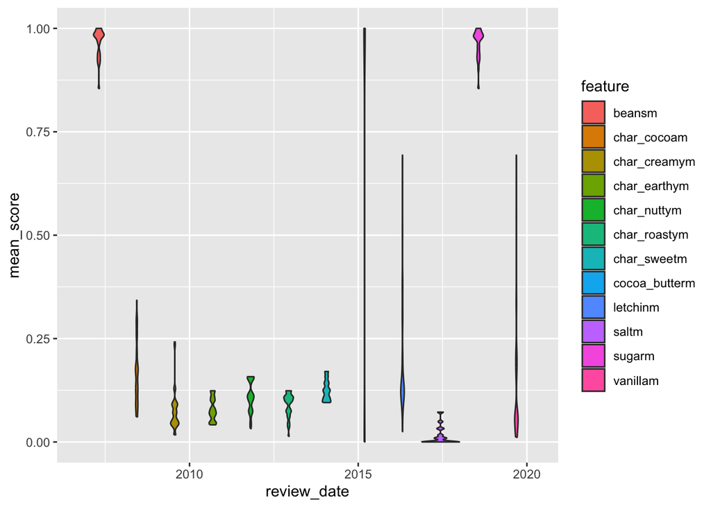

```r
newchocolate4 %>% ggplot(aes(x = review_date, y = mean_score, fill = feature)) + geom_violin()
```

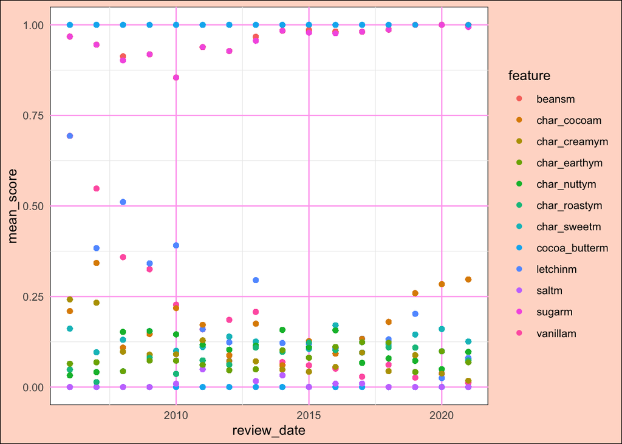

```r
newchocolate4 %>% ggplot(aes(x = review_date, y = mean_score, colour = feature)) + geom_point() + theme_minimal() + theme(plot.background = element_rect(fill = "#FFdBCD"), panel.background = element_rect(fill = "white"), panel.grid.major = element_line(color = "#FFaAF0"))
```

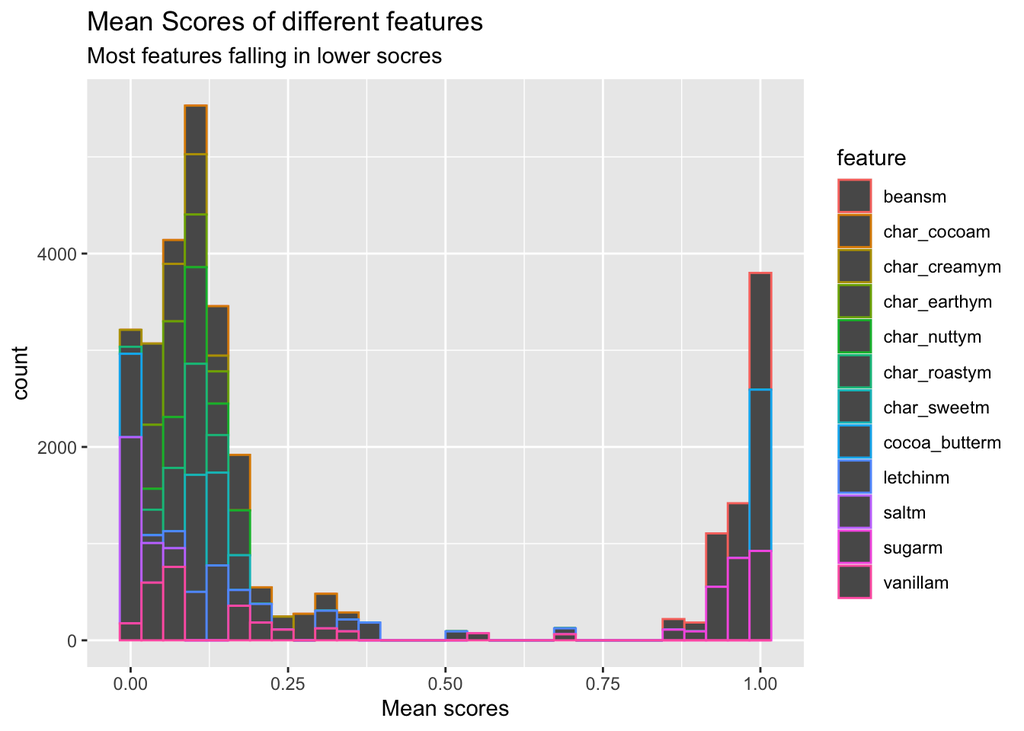

```r
newchocolate4 %>% ggplot(aes(mean_score, colour = feature)) + geom_histogram() + labs(title = "Mean Scores of different features", subtitle = "Most features falling in lower socres", x= "Mean scores")
```

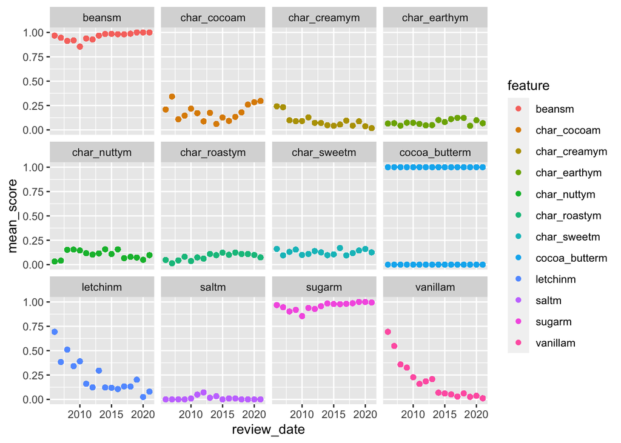

```r
newchocolate4 %>% ggplot(aes(x = review_date, y = mean_score, colour = feature)) + geom_point() + facet_wrap(~feature)
```

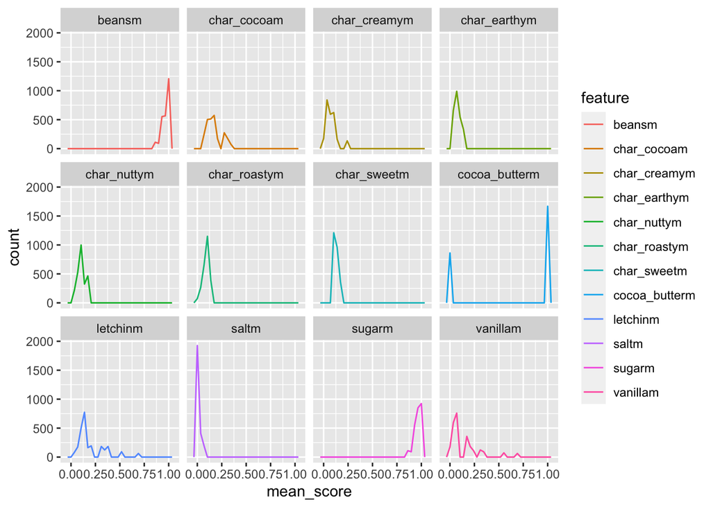

```r
newchocolate4 %>% ggplot(aes(mean_score, colour = feature)) + geom_freqpoly() + facet_wrap(~feature)
```

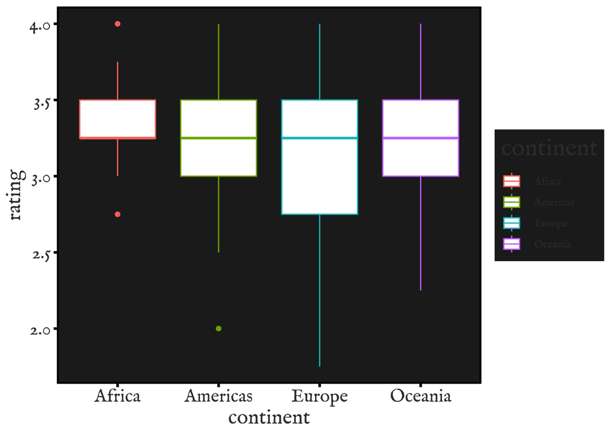

```r
chocolate6 %>% ggplot(aes(x = continent, y = rating, colour = continent)) + geom_boxplot() + theme_minimal() + ThemePark::theme_oppenheimer()
```

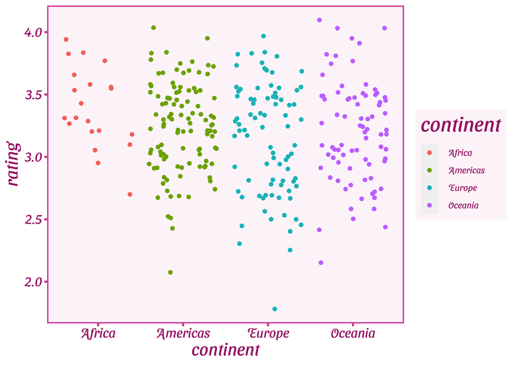

```r
chocolate6 %>% ggplot(aes(x = continent, y = rating, colour = continent)) + geom_jitter() + ThemePark::theme_barbie()
```

#### Answer:

##### 1. I fill each “violin” with different colors, making the graph visually appealing and meaningful.

##### 2. I change the theme by increasing the panel background, plot background, and panel grid, which makes it more beautiful.

##### 3. I add the title, subtitle, and x axis labers, making it more clear to understand.

##### 4. I make the graph divided into 12 panels according to features, making it easier to find the different tendencies over time between different features.

##### 5. I choose using “geom_freqpoly()” to show the characteristics of the data, which makes it more obvious.

##### 6. I choose using “boxplot” to show the characteristics of data, making it more easier to compare the distribution between different continents. Also, I use the “oppenheimer” theme to make it look cool.

##### 7. I change the theme to “Barbie them”, and change the typer of graph. Compared to boxplot, “jitter” could show individual values, which is useful when I focus on the individual values, rather than group values.